# Bat Bioacoustics

Code based on documentation on https://revspace.nl/StereoBatRecorder

Main steps:

- A Butterworth filter is used to filter out low frequencies
- The continuous spectral entropy is calculated as a means to separate parts of the signal containing possible bat calls from the rest of the signal
- The lag between the left and right channels is calculated using the cross-covariance. The absolute values of the hilbert transform of the correlations are then taken to smooth out a plot showing the correlation vs. time lag.

TODO:

- The processing steps should be a bit more modular with tests showing how well they perform. For example, the code that isolates the calls from the rest of the signal is ok, but could use a bit more work.
- Try out a few ideas for species identification.

## Load the required libraries

```r
options(stringsAsFactors = FALSE) #never ever ever convert strings to factors

library(tuneR) #readWave
source("/home/cbdavis/Desktop/tuneR/R/readWave.R") # patched version of readWave
library(seewave)
library(signal) # Matlab-style filters
```

```r
library(ggplot2) # plotting
library(sqldf) # run SQL queries over data frames
baseDir = "/home/cbdavis/projects/BioAcoustics/Bats/stereobat"  # base directory for recordings, recursive search is done from here
```

## Define the Butterworth filter

```r
highPassFilter <- function(originalWave){
  tmp = butter(4, 0.2, "high")
  a = tmp$a
  b = tmp$b

  filteredWave = Wave(left = as.numeric(filter(b, a, originalWave@left)),
                      right = as.numeric(filter(b, a, originalWave@right)),
                      samp.rate = originalWave@samp.rate,
                      bit = originalWave@bit,
                      pcm = originalWave@pcm)
  return(filteredWave)
}
```

## Process all recordings

This iterates over all the files and uses the Continuous Spectral Entropy to segment calls from the rest of the signal. For each of the segments, the time lag between the microphones is calculated.

```r
windowLength = 256

files = list.files(path=baseDir, pattern="*.wav", recursive=TRUE, full.names=TRUE)

lagData = data.frame()
entropy_df = data.frame()
for (file in files){
  originalWave = readWave(file)
  filteredWave = highPassFilter(originalWave)
  rm(originalWave)

  cutoffValue = 0.9
  csh = csh(filteredWave, wl=windowLength, ovlp=0, plot=FALSE)
  csh_time = csh[,1]
  csh_values = csh[,2]

  # in the seewave package, the autoc and fund functions should be helpful in refining this further.
  # The Continuous Spectral Entropy is ok, but still misses some parts and falsely identifies some parts of the signal

  entropy_df = rbind(entropy_df,
                     data.frame(fullPath = file,
                                csh_time = csh_time,
                                csh_values = csh_values,
                                csh_cutoff = max(csh_values) * cutoffValue))

  # Now segment the audio based on the entropy values.  Use a time buffer before and after.
  sampleCount = 1
  audioBuffer = 0.025
  audioSegments = list()
  locs = which(csh_values < max(csh_values) * cutoffValue)
  startLoc = locs[1]
  for (i in c(2:(length(locs)-1))){
    if ((locs[i+1] - locs[i]) > 1){
      endLoc = locs[i]
      if ((endLoc - startLoc) > 5){ # TODO figure out a smarter way of figuring out if the signal is long enough
        # cutw only returns a mono signal if a stereo signal is used as input,
        # so we perform cuts on both channels independently

        audioStart = csh_time[startLoc]-audioBuffer

        # make sure don't have negative starting value for the time
        if (audioStart < 0){
          audioStart = 0
          }

        audioEnd = csh_time[endLoc] + audioBuffer

        # Turn on plot=TRUE to see way too many graphs
        audioSegmentLeft = as.numeric(cutw(filteredWave@left,
                                           f=filteredWave@samp.rate,
                                           from=audioStart,
                                           to=audioEnd,
                                           plot=FALSE, output="matrix"))
        audioSegmentRight = as.numeric(cutw(filteredWave@right,
                                            f=filteredWave@samp.rate,
                                            from=audioStart,
                                            to=audioEnd,
                                            plot=FALSE, output="matrix"))
        audioSegment = Wave(audioSegmentLeft, audioSegmentRight, samp.rate = filteredWave@samp.rate, bit=filteredWave@bit)
        audioSegments = c(audioSegments, audioSegment)

        # TODO lag.max is completely made up, should be set to something sensible based on max tdiff between microphones
        xcov_info = ccf(audioSegment@left, audioSegment@right, lag.max=250, type="covariance", plot=FALSE)
        lag = xcov_info$lag
        r = xcov_info$acf
        # take absolute value of the hilbert transform to get the envelope of the correlation
        r2 = abs(hilbert(r, filteredWave@samp.rate))
        # normalize r2
        r2 = (r2 - min(r2))/(max(r2) - min(r2))
        lagData = rbind(lagData, cbind(file,
                                       gsub(paste(baseDir, "/", sep=""), "", file),
                                       sampleCount,
                                       audioStart,
                                       audioEnd,
                                       lag*((1/audioSegment@samp.rate)*1000),
                                       r2))
        sampleCount = sampleCount + 1
        }
      startLoc = locs[i+1]
      }
    }
  }

entropy_df$relativePath = gsub(paste(baseDir, "/", sep=""), "", entropy_df$fullPath)
```

## Continuous Spectral Entropy with Cutoff Value Used for Segmentation

Parts of the audio signal with entropy values lower than the cutoff (in red) are kept for further analysis

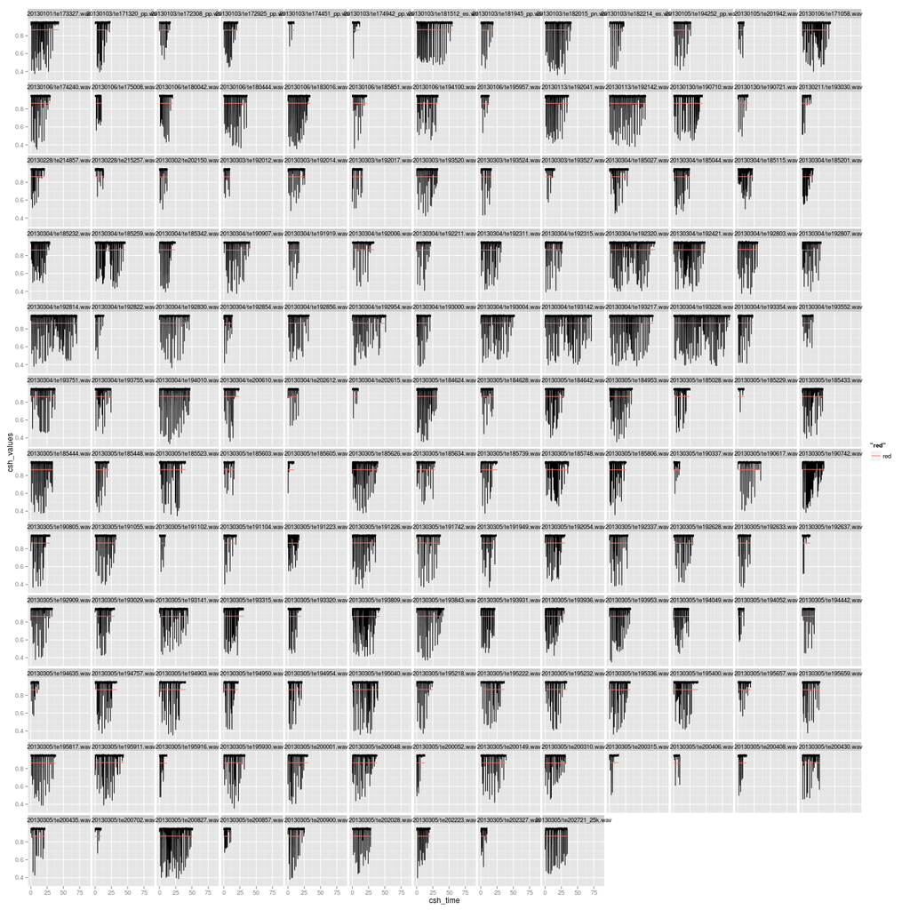

```r
ggplot(entropy_df, aes(x=csh_time, y=csh_values)) + geom_line() +
  geom_line(aes(x=csh_time, y=csh_cutoff, colour="red")) +
  facet_wrap(~relativePath)
```

## Time Lag Between Microphone Channels

Points indicate max correlation, with the correlation values scaled from 0 to 1 for plotting purposes. The vertical semi-transparent lines are actually polygons, with the width representing the correlation at a particular lag value.

```r
colnames(lagData) = c("fullPath", "relativePath", "sample", "audioStart", "audioEnd", "lag", "r")

lagData$audioStart = as.numeric(lagData$audioStart)
lagData$audioEnd = as.numeric(lagData$audioEnd)
lagData$r = as.numeric(lagData$r)
lagData$lag = as.numeric(lagData$lag)

maxCorrelations = sqldf("select *, max(r) from lagData group by sample, fullPath")
```

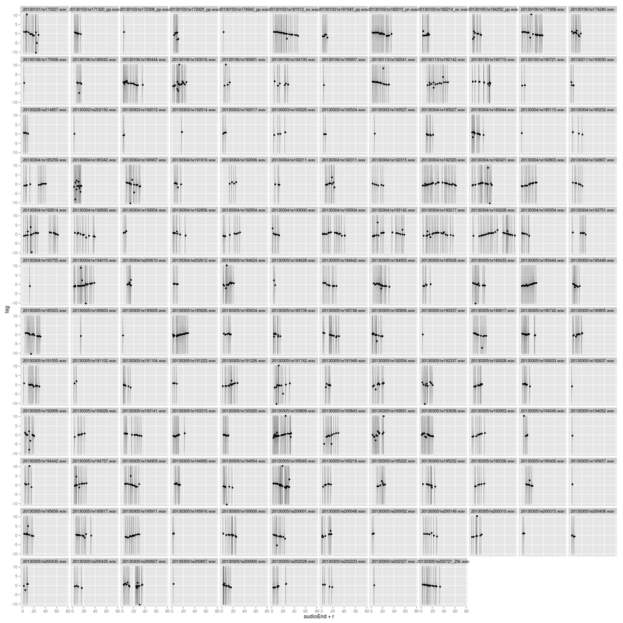

```r
maxCorrelations$audioStart = as.numeric(maxCorrelations$audioStart)
maxCorrelations$audioEnd = as.numeric(maxCorrelations$audioEnd)
maxCorrelations$r = as.numeric(maxCorrelations$r)
maxCorrelations$lag = as.numeric(maxCorrelations$lag)

# set correlations for min & max lag (the boundaries of the window) to zero
# this helps to draw the polygons correctly
lagData$r[which(lagData$lag == max(lagData$lag))] = 0
lagData$r[which(lagData$lag == min(lagData$lag))] = 0

lagData = sqldf("select * from lagData order by fullPath, sample, lag")

ggplot(lagData) + geom_line(aes(x=audioEnd+r, y=lag, group=sample), alpha=0.25) +
  geom_point(data=maxCorrelations, aes(x=audioEnd+r, y=lag)) + facet_wrap(~relativePath)
```